```python
import pandas as pd
import seaborn as sns
import matplotlib.pyplot as plt
%matplotlib inline
```

# Intro

**How do we beat top-ranking Wikipedia content?**

We suppose that Wikipedia is facing the common problem as pages in Google. Highly popular articles are popular also because they have a lot of backlinks or pages that are redirected to them. Imagine you're a journalist or a active blogger writing about an article on Afghanistan news. You google and enter the `Afghanistan` article on Wikipedia to get the resources quickly. Entering wikipedia articles through search engines such as Google can be tricky because even if it yields decent amount of content, you will never find an unpopular Wikipedia page. Once you find enough content on Wikipedia, you'll return to your adored search engine. So, why would you keep searching for that unpopular `inexistent` page?

Our goal is to showcase articles which may be less popular so that you can be informed by facts and topics you may search or need using English Wikipedia. This can help promote less visible articles so that they can be improved, edited, viewed and thus contribute to our knowledge of the on-going events!

Also, for a journalist, it may really be helpful because instead of covering incredibly adverstised topics, they may get the opportunity to be the first to right their own story about an uncovered subject. Their research can improve the article visibility and give more importance to a hidden world.

We hypothesize that unkown articles are not necessarily unimportant!

In order to estimate the popularity of the wikipedia articles, we came up with some metrics. They don't suddenly pop into your head and bang! Instead, good ol'intuition and some good references ([1](https://en.wikipedia.org/wiki/Help:Drawing_attention_to_new_pages#How_do_I_get_others_to_notice_the_page_I_just_created?)) and ([2](https://en.wikipedia.org/wiki/Wikipedia:Pageview_statistics#What_factors_can_increase_a_page's_viewing?)) became a good indicator to select our candidates.

4 characteristics of an article could be used to identify the popularity of an article:

- [ ] page references
- [ ] page views
- [ ] external links
- [ ] article length

As a pilot-phase, we focus solely on articles that all have as common subject: civilian attack, civil conflict, military conflict.

If you want to know more, sit back & enjoy the ride!

# Digging into references

Translating that intuition into a number isn't easy. One thing we might try is looking at the number of references in a an article. References are used by the writer of the article to justify and cite the content present in the article. References are thus synonym of quality, in the context of a collaborative and openly enditable encyclopedia such as Wikipedia.

We think that the references that are found at the bottom of the page of the articles could partially encapsulate the popularity of that article. So we analyze the references for each article.

- 75 % of the articles have only 19 references. The maximum number of articles in a page reaches 1000 references!

This leads to another question!

**What kind of references are hidden among this data?**

Let's have a look at the most commonly occurring references in the data. Also what is the trend?

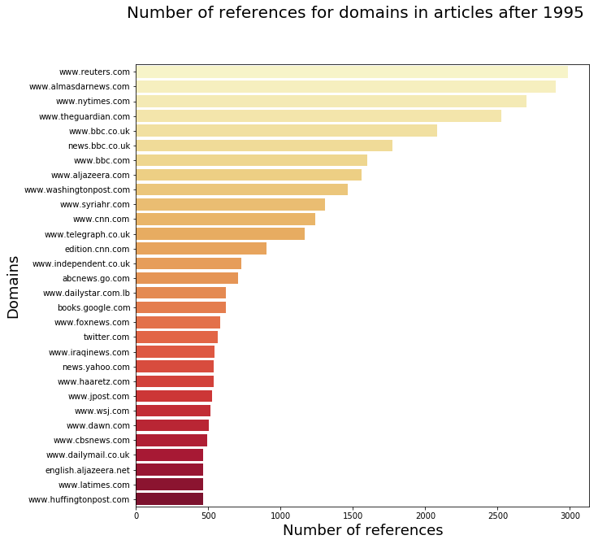

```python
domains_distribution_pd30 = domains_distribution_pd.head(30)

# plot using bar plot
f, ax1 = plt.subplots()
plt.sca(ax1)
sns.barplot(domains_distribution_pd30['nb_ref'], domains_distribution_pd30.index, palette="YlOrRd", ax=ax1, orient='h')
plt.xlabel('Number of references',fontsize=18)
plt.ylabel('Domains',fontsize=18)
f.suptitle('Number of references for domains in articles after 1995', fontsize=20)
f.set_size_inches(10, 10)
plt.show()
```

For recent wikipedia conlfict-related articles (after 1995) most of the references come from the American, English and Arab media. American and English sources are no surprise as we are working with the English version of Wikipedia. In the top 5, [reuters](https://www.reuters.com) is the first! Interestingly, [almasdarnews](https://www.almasdarnews.com) is a close second. This online media source covers mostly conflicts in the Middle East: Syria, Yemen, and Iraq.

That's one down, three more to go!

- [x] Number of references
- [ ] Number of views
- [ ] Article length
- [ ] Number of external links

# What about our other candidates?

Article length speaks for itself. The longer an article, the more likely it was edited and developed to fully cover the article topic. Looking at the number of views per page is also an important factor affecting the popularity of an article. Finally, the number of external links corresponds to the incoming links from other articles within Wikipedia.

Why not follow the trend?

Exploring our other indicators of popularity 'article length', 'number of views', 'number of external links', let's see if these choices actually contribute to popularity of an article! To do so, we plot one indicator with respect to the other: we analyze if variables are either monotonic or independent, i.e. if article length increases, number of external links increases or does not vary. Imagine if 'article length' increases and at the same time 'number of views' decreases! Summing them up into popularity score would mean adding a negative coefficient otherwise the effect of one will partially cancel out the effect of the other one.

|  | article_lenght | views | refs_count | link_count |
| --- | --- | --- | --- | --- |
| article_lenght | 1.000000 | 0.619499 | 0.715575 | 0.892395 |
| views | 0.619499 | 1.000000 | 0.477095 | 0.625089 |
| refs_count | 0.715575 | 0.477095 | 1.000000 | 0.582192 |
| link_count | 0.892395 | 0.625089 | 0.582192 | 1.000000 |

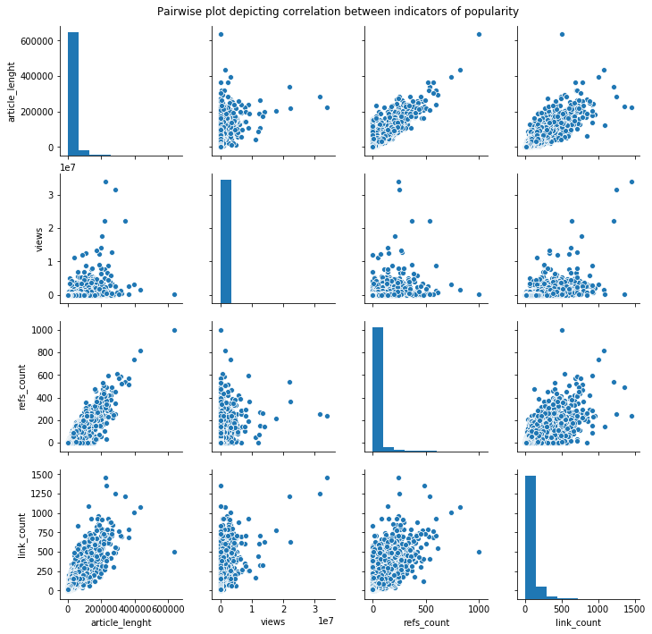

```python
articles = pd.read_csv('../data/data_processed/data_processed.csv', index_col=0)
articles.index.names = ['id']
articles.head()
articles.end_date_clean = articles.end_date_clean.fillna(0)
ax = sns.pairplot(data=articles, vars=['article_lenght', 'views', 'refs_count', 'link_count']);
plt.subplots_adjust(top=0.95)
ax.fig.suptitle("Pairwise plot depicting correlation between indicators of popularity");
articles[['article_lenght', 'views', 'refs_count', 'link_count']].corr(method='spearman')
```

- [x] Number of references
- [x] Number of views
- [x] Article length
- [x] Number of external links

# Popularity score

Having chosen our four features for quantifying the popularity of a page, and standardizing them to have them on the same range, we can compute the popularity score of an article.

For each article *x*, the popularity score is defined as:

$score(x) = length(x) + views(x) + refs(x) + links(x)$

where

- length is the scaled length of the article x
- views are the scaled number of views of the article x
- refs are the scaled number of references of the article x
- links are the scaled number of external links of the article x

# Survey

We want to double check that our score is correlated with what people think. We wrote a survey in order to verify that our metric is accurate.

We collected 2088 answers from more than 20 people. The user choices between left, right or 'Skip' in order to indicate the most popular conflict between the 2 proposed conflicts, i.e. it is a binary survey.

The coverage of the survey is not incredible (12%) because we have more than 17 000 articles that can be used to write the survey, and some are really really unknown. Therefore, we randomly selected only articles that correspond to the middle to the top part of our popularity ranking.

We counted the number of correct answer for each popularity duel and we found out that 94 % of the answers to the questionaire match our popularity score, not bad!

The metric thus seems to capture the popularity of the article. In this 6% of error, most of the errors seem to come more often from a missclick or a confusion rather than an error in our metric. For instance, two users thought that World War I is less popular than 2009 Jaipur fire or Battle of Adwa, which seems a bit unrealistic. Another group of errors arise from 2 unknown conflicts, like 2008 Bin Salman mosque bombing vs the Battle of Marawi. Having established that the metric seems realistic, we continue our investigation by looking at the findings our metric will give: spot important unpopular conflicts!

### Article popularity

```python
all_metrics_articles = pd.read_csv('../data/data_processed/NAS_articles_popularity_score.csv', index_col=0)
```

```python
all_metrics_articles.sort_values(by='popularity_score', ascending=False).shape
```

```
(17467, 15)
```

```python
all_metrics_articles['popularity_score'].describe().T
```

```
count    17467.000000
mean         0.106581
std          0.149411
min          0.001267
25%          0.033244
50%          0.059036
75%          0.117079
max          2.588225
Name: popularity_score, dtype: float64
```

```python
pops = all_metrics_articles.sort_values(by='popularity_score', ascending=False).head()
middle_pop = pd.DataFrame(all_metrics_articles.loc[34975490]).T
no_pops = all_metrics_articles.sort_values(by='popularity_score', ascending=True).head()
```

```python
best_worst_pops = pd.concat([no_pops, middle_pop, pops])
best_worst_pops
```

|  | title | categories | scaled_length | scaled_views | scaled_refs | scaled_links | death | locations | end_date_clean | ongoing | popularity_score | article_lenght | views | refs_count | link_count |
| --- | --- | --- | --- | --- | --- | --- | --- | --- | --- | --- | --- | --- | --- | --- | --- |
| 49532277 | Hashimiya attack | civilian attack | 0.000558319 | 2.10427e-05 | 0 | 0.000687285 | 75 | Hashimiya\|Iraq | 2014 | False | 0.00126665 | 881 | 753 | 0 | 2 |
| 58421339 | Fifth Third Center shooting | civilian attack | 0.000430928 | 4.31494e-05 | 0.001 | 0.000687285 | 0 | NaN | 0 | False | 0.00216136 | 800 | 1501 | 1 | 2 |
| 49429205 | January 2015 Maiduguri suicide bombing | civilian attack | 0.000470246 | 1.12011e-05 | 0.001 | 0.00206186 | 19 | Maiduguri\|Nigeria | 0 | False | 0.0035433 | 825 | 420 | 1 | 4 |
| 50567259 | Transkei War | military conflict | 0.000786365 | 1.88557e-05 | 0 | 0.00274914 | 7000 | South Africa Q258 | 1836 | False | 0.00355436 | 1026 | 679 | 0 | 5 |
| 56640476 | Operation of Sidi Aïch | military conflict | 0.00287023 | 4.87647e-06 | 0.001 | 0 | 0 | Sidi Aïch\|Tunisia | 2015 | False | 0.00387511 | 2351 | 206 | 1 | 1 |
| 34975490 | 2012 Bucharest hair salon shooting | civilian attack | 0.0174903 | 0.000127379 | 0.018 | 0.0233677 | 2 | Bucharest Q19660 | 2012 | False | 0.0589854 | 11647 | 4351 | 18 | 35 |
| 32927 | World War II | military conflict | 0.350225 | 1 | 0.238 | 1 | 73000000 | Russia Q159\|Europe Q46\|Africa Q15\|Pacific ... | 1945 | False | 2.58822 | 223212 | 33835972 | 238 | 1456 |
| 32611 | Vietnam War | military conflict | 0.534488 | 0.652728 | 0.536 | 0.832302 | 950765 | South Vietnam Q180573 | 1975 | False | 2.55552 | 340373 | 22085710 | 536 | 1212 |
| 4764461 | World War I | military conflict | 0.4461 | 0.930421 | 0.254 | 0.860481 | 17000000 | Europe Q46\|Australia and Oceania Q55643\|Mi... | 1918 | False | 2.491 | 284173 | 31481685 | 254 | 1253 |
| 52019122 | Battle of Mosul (2016–2017) | military conflict | 1 | 0.00491495 | 1 | 0.341581 | 9100 | Erbil Governorate Q213189\|Nineveh Governora... | 2017 | False | 2.3465 | 636363 | 166343 | 1000 | 498 |
| 46230181 | Saudi Arabian-led intervention in Yemen | military conflict | 0.683026 | 0.0466836 | 0.818 | 0.738144 | 0 | Yemen Q805 | 0 | True | 2.28585 | 434819 | 1579624 | 818 | 1075 |

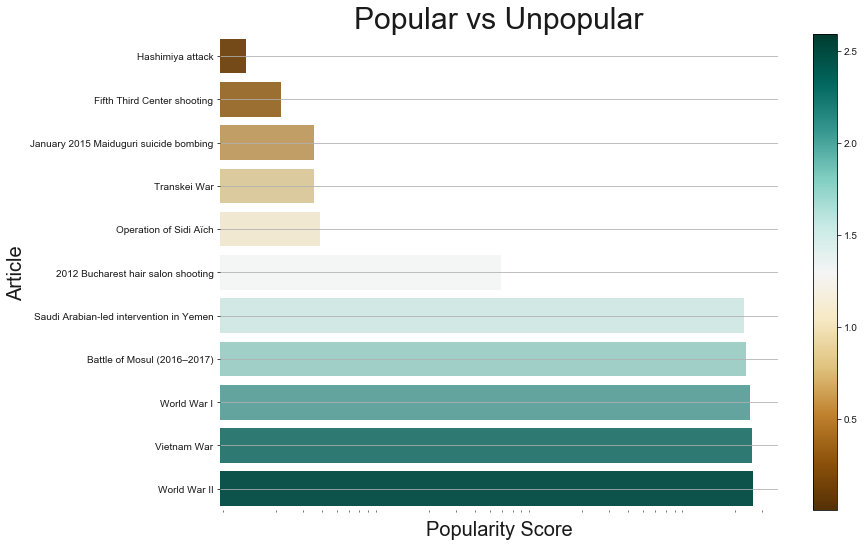

```python
sort_best_worst_pops=best_worst_pops.sort_values(by='popularity_score')
f, axx = plt.subplots(figsize=(13, 8))
plot = plt.scatter(sort_best_worst_pops.title, sort_best_worst_pops.popularity_score,
                   c=sort_best_worst_pops.popularity_score,
                   cmap='BrBG')
plt.clf()
plt.colorbar(plot)
g = sns.barplot(
    x='popularity_score', y='title', data=sort_best_worst_pops, palette='BrBG')
g.set_xscale('log')
sns.despine(left=True, bottom=True)
g.axes.set_title("Popular vs Unpopular",fontsize=30)
g.set_xlabel("Popularity Score",fontsize=20)
g.set_ylabel("Article",fontsize=20)
sns.set(style="whitegrid")
plt.grid(axis='both')
plt.tight_layout()
plt.xticks([])
plt.show()
```

Not suprisingly, World War II is the most popular page! It has the highest popularity score of 2.59, with

- article length: 223212
- views: 33835972
- references: 238
- external links: 1456

World War II being the most popular article hints that our metrics may be enough to encapsulate the popularity of a page. Because who hasn't studied World War II in school and looked up this article on Wikipedia?

# Is there a pattern between event date and popularity score?

We wonder if the attribution of the popularity score is partially influenced because of the event date and the importance of the article. By event date, we refer to the actual end date of the conflict the article is referring to (as our articles talk about conflicts). For now, the importance of an article is quantified by the number of deaths during that event.

Let's first have a quick look at the distribution of the article end dates.

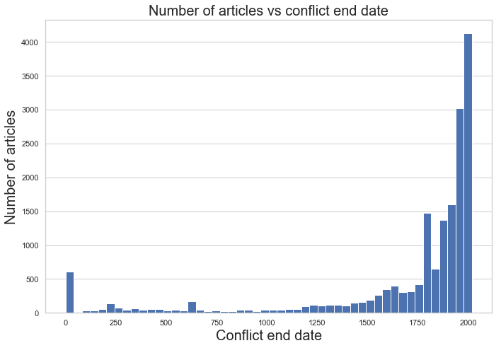

```python
d = all_metrics_articles['end_date_clean'].hist(figsize=(10, 7), bins=50);
d.axes.set_title("Number of articles vs conflict end date",fontsize=20)
d.set_xlabel("Conflict end date",fontsize=20)
d.set_ylabel("Number of articles",fontsize=20)
plt.grid(axis='x')
plt.tight_layout()
plt.show()
```

The plot gives us a very broad range of conflict end dates. Since we are interested in more recent conflicts, as a first approach why don't we have a look at articles mentionning a conflict end date after 1910.

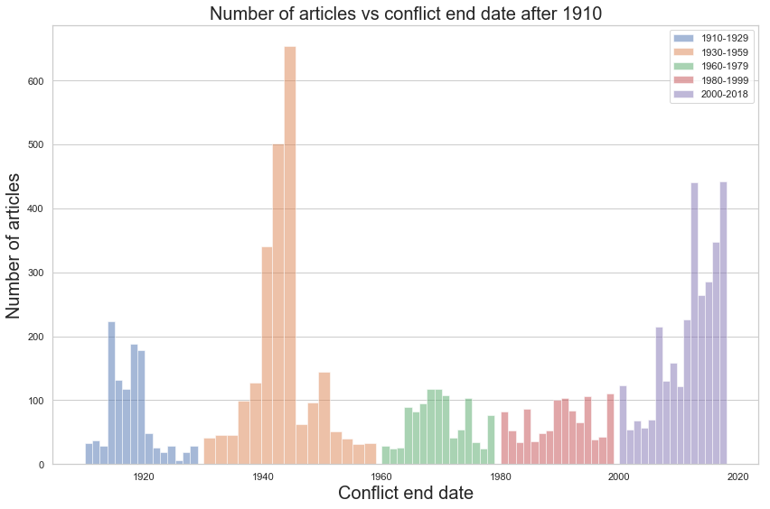

```python
f = all_metrics_articles['end_date_clean'][(all_metrics_articles['end_date_clean'] >= 1910) &
                                           (all_metrics_articles['end_date_clean'] < 1930)
                                          ].hist(figsize=(12, 8), bins=15, alpha=0.5, label='1910-1929');
all_metrics_articles['end_date_clean'][(all_metrics_articles['end_date_clean'] >= 1930) &
                                           (all_metrics_articles['end_date_clean'] < 1960)
                                          ].hist(figsize=(12, 8), bins=15, alpha=0.5, label='1930-1959');
all_metrics_articles['end_date_clean'][(all_metrics_articles['end_date_clean'] >= 1960) &
                                           (all_metrics_articles['end_date_clean'] < 1980)
                                          ].hist(figsize=(12, 8), bins=15, alpha=0.5, label='1960-1979');
all_metrics_articles['end_date_clean'][(all_metrics_articles['end_date_clean'] >= 1980) &
                                           (all_metrics_articles['end_date_clean'] < 2000)
                                          ].hist(figsize=(12, 8), bins=15, alpha=0.5, label='1980-1999');
all_metrics_articles['end_date_clean'][(all_metrics_articles['end_date_clean'] >= 2000) &
                                           (all_metrics_articles['end_date_clean'] < 2019)
                                          ].hist(figsize=(12, 8), bins=15, alpha=0.5, label='2000-2018');

f.axes.set_title("Number of articles vs conflict end date after 1910",fontsize=20)
f.set_xlabel("Conflict end date",fontsize=20)
f.set_ylabel("Number of articles",fontsize=20)
plt.grid(axis='x')
plt.tight_layout()
plt.legend(loc='upper right')
plt.show()
```

Roughly five distinct population of articles are observed. The first peak around 1914 corresponds to World War I. Indeed, 1113 of our filtered articles have a end conflict end date between 1910-1930. The second peak around 1945 corresponds to World War 2, with more than 2300 articles belonging to that particular end conflict date. We can see that around an important conflict end date such as 1945, a lot of articles have talked about that conflict, making it even more significant in Wikipedia!

Since, we are more interesteted in recent events, let's fast-forward to 2017-2018. We are looking at article's describing ongoing conflicts.

```python
all_metrics_articles[(all_metrics_articles['end_date_clean'] >= 2017) &
                                           (all_metrics_articles['end_date_clean'] < 2019)].shape
```

```
(442, 15)
```

```python
# bar plot ongoing conclusion
data_2017_2018 = all_metrics_articles[all_metrics_articles['ongoing']==True]
data_2017_2018.shape
```

```
(32, 15)
```

# Ongoing conflicts

Here, we look at the recent ongoing conflicts, and analyze the popularity of each article between 2017-2018. Most popular articles deal with the Yemen and Syria conflicts.

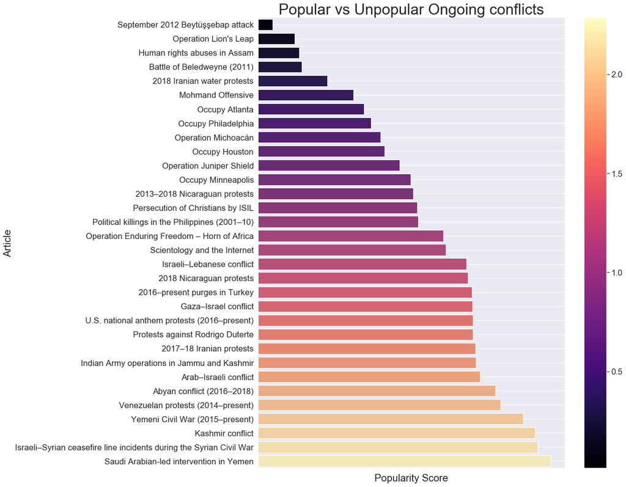

```python
sort_data_2017_2018=data_2017_2018.sort_values(by='popularity_score')
sns.set(font_scale=1.5)
f, axx = plt.subplots(figsize=(18, 14))
plot = plt.scatter(sort_data_2017_2018.title, sort_data_2017_2018.popularity_score,
                   c=sort_data_2017_2018.popularity_score,
                   cmap='magma')
plt.clf()
plt.colorbar(plot)
g = sns.barplot(
    x='popularity_score', y='title', data=sort_data_2017_2018, palette='magma')
g.set_xscale('log')
sns.despine(left=True, bottom=True)
g.axes.set_title("Popular vs Unpopular Ongoing conflicts",fontsize=30)
g.set_xlabel("Popularity Score",fontsize=20)
g.set_ylabel("Article",fontsize=20)
sns.set(style="whitegrid")
plt.grid(axis='both')
plt.tight_layout()
plt.xticks([])
plt.show()
```

Let's have a closer look at the unpopular articles. We want to understand if unpopular articles are unpopular because they are not "important" enough. Therefore, we decide to look at the number of deaths associated to each conflict.

```python
sort_data_2017_2018[sort_data_2017_2018['death']>0]
```

| id | title | categories | scaled_length | scaled_views | scaled_refs | scaled_links | death | locations | end_date_clean | ongoing | popularity_score | article_lenght | views | refs_count | link_count |
| --- | --- | --- | --- | --- | --- | --- | --- | --- | --- | --- | --- | --- | --- | --- | --- |
| 36904359 | September 2012 Beytüşşebap attack | military conflict | 0.002578 | 0.000136 | 0.003 | 0.006873 | 21 | Beytüşşebap Q853401 | 0.0 | True | 0.012587 | 2165 | 4654 | 3 | 11 |
| 18695217 | Operation Michoacán | military conflict | 0.022894 | 0.000811 | 0.023 | 0.048110 | 150 | Michoacán Q79861 | 0.0 | True | 0.094815 | 15083 | 27471 | 23 | 71 |
| 28049183 | Political killings in the Philippines (2001–10) | civilian attack | 0.043730 | 0.000787 | 0.029 | 0.118900 | 1200 | Philippines Q928 | 0.0 | True | 0.192417 | 28331 | 26669 | 29 | 174 |
| 8812611 | Operation Enduring Freedom – Horn of Africa | military conflict | 0.091072 | 0.004951 | 0.094 | 0.116151 | 41 | Horn of Africa Q40556 | 0.0 | True | 0.306174 | 58433 | 167555 | 94 | 170 |
| 6020082 | Israeli–Lebanese conflict | military conflict | 0.118738 | 0.009654 | 0.130 | 0.213058 | 17500 | Israel Q801 | 0.0 | True | 0.471450 | 76024 | 326679 | 130 | 311 |
| 16346266 | Gaza–Israel conflict | military conflict | 0.138751 | 0.013458 | 0.165 | 0.213746 | 100 | hlist Gaza Strip Southern District Israel ... | 0.0 | True | 0.530955 | 88749 | 455401 | 165 | 312 |
| 56158430 | 2017–18 Iranian protests | civil conflict | 0.175731 | 0.009483 | 0.176 | 0.195876 | 30 | Iran Q794 | 0.0 | True | 0.557090 | 112262 | 320913 | 176 | 286 |
| 56082093 | Indian Army operations in Jammu and Kashmir | military conflict | 0.202303 | 0.000595 | 0.241 | 0.118900 | 2018 | Jammu and Kashmir Q1180 | 0.0 | True | 0.562799 | 129158 | 20172 | 241 | 174 |
| 7960202 | Arab–Israeli conflict | military conflict | 0.152627 | 0.035753 | 0.137 | 0.284536 | 25343 | Middle East Q7204 | 0.0 | True | 0.609917 | 97572 | 1209791 | 137 | 415 |
| 56944198 | Abyan conflict (2016–2018) | military conflict | 0.255367 | 0.000067 | 0.473 | 0.083162 | 288 | Abyan Governorate Q241774 | 0.0 | True | 0.811596 | 162898 | 2319 | 473 | 122 |
| 46215853 | Yemeni Civil War (2015–present) | military conflict | 0.447354 | 0.073866 | 0.454 | 0.385567 | 15035 | Yemen Q805\|Najran Region Q464718 | 0.0 | True | 1.360786 | 284970 | 2499360 | 454 | 562 |
| 43227423 | Israeli–Syrian ceasefire line incidents during... | military conflict | 0.359331 | 0.001885 | 0.488 | 0.932646 | 2018 | Syria Q858 | 0.0 | True | 1.781862 | 229002 | 63827 | 488 | 1358 |

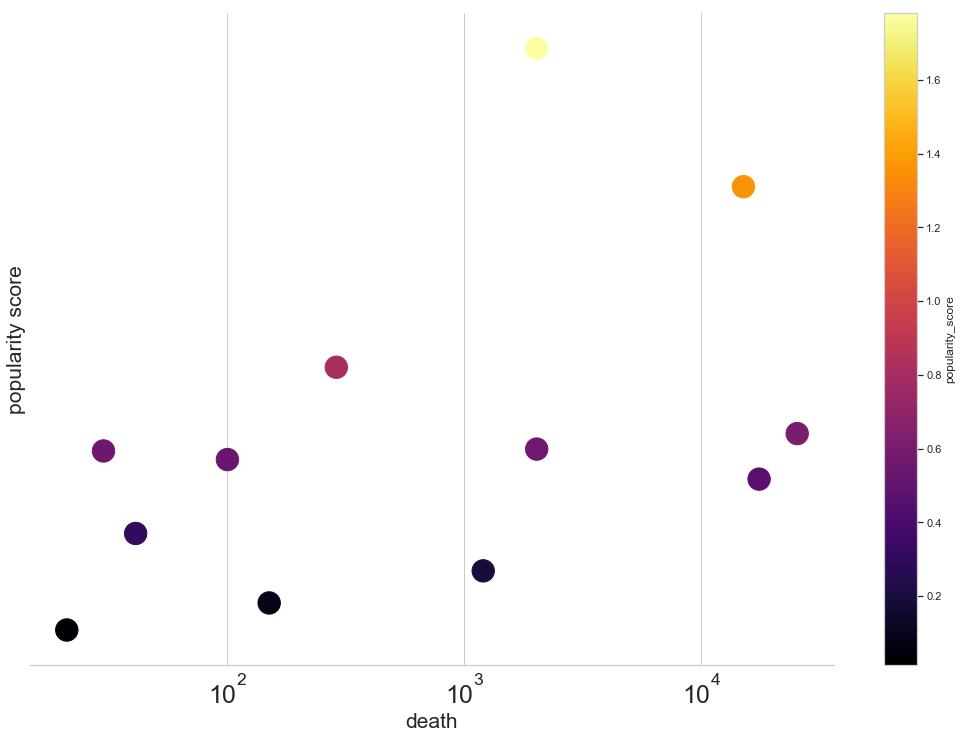

```python
ax = sort_data_2017_2018[sort_data_2017_2018.death > 0].plot.scatter(x='death',
                        y='popularity_score',c='popularity_score',
                        figsize=(18,12),fontsize = 25,
                        colormap='inferno',sharex=False, s = 500)


ax.set_xlabel('death', fontsize=21)
ax.set_ylabel('popularity score', fontsize=21)
plt.xscale('symlog')
sns.despine(left=True, bottom=False)
plt.grid(axis='y')
plt.yticks([])
plt.show();
```

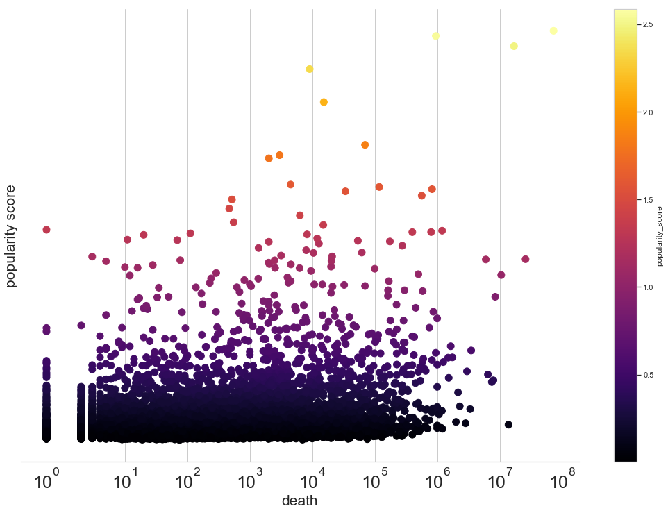

```python
ax = all_metrics_articles[all_metrics_articles.death > 0].plot.scatter(x='death',
                        y='popularity_score',c='popularity_score',
                        figsize=(18,12),fontsize = 25,
                        colormap='inferno',sharex=False, s = 100)


ax.set_xlabel('death', fontsize=21)
ax.set_ylabel('popularity score', fontsize=21)
plt.xscale('symlog')
sns.despine(left=True, bottom=False)
plt.grid(axis='y')
plt.yticks([])
plt.show();
```

# Conclusion

Looking at articles in the recent years, we found that some unpopular articles may be not be completly unsignificant as these conflicts involve an considerable number of deaths. To live in a better world people must be aware of unpopular conflicts that have a high number of death! People will not have easily access to such articles because they are not cited very often, they do not appear in Google search, they even do not appear in the first pages of the wikipedia search. A way to overcome this barrier could be to monthly showcase these articles on the wikipedia front page. With this project we proposed an easy way (4 factors) of finding unpopular articles which could be improved in order to raise awardness on unknown conflicts involving victims.

# Do not include STOP

```python
date_ranges = [1990, 2000, 2010, 2019]
articles_with_cat = all_metrics_articles.copy()
articles_with_cat['date_range'] = ''
articles_with_cat['date_range'][
    (articles_with_cat['end_date_clean'] >= date_ranges[0]) & (articles_with_cat['end_date_clean'] < date_ranges[1])
] = '{}-{}'.format(date_ranges[0], date_ranges[1] - 1)

articles_with_cat['date_range'][
    (articles_with_cat['end_date_clean'] >= date_ranges[1]) & (articles_with_cat['end_date_clean'] < date_ranges[2])
] = '{}-{}'.format(date_ranges[1], date_ranges[2] - 1)

articles_with_cat['date_range'][
    (articles_with_cat['end_date_clean'] >= date_ranges[2]) & (articles_with_cat['end_date_clean'] < date_ranges[3])
] = '{}-{}'.format(date_ranges[2], date_ranges[3] - 1)
```

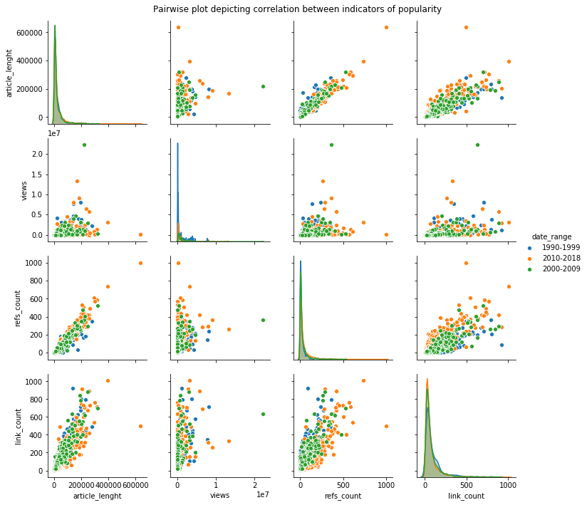

```python
ax = sns.pairplot(data=articles_with_cat,
                  vars=['article_lenght', 'views', 'refs_count', 'link_count'],
                  hue='date_range');
plt.subplots_adjust(top=0.95)
ax.fig.suptitle("Pairwise plot depicting correlation between indicators of popularity");
```

[output not shown]

[figure not shown]

```python
ax = sns.pairplot(data=articles_with_cat,
                  vars=['refs_count', 'link_count'],
                  hue='date_range', kind='reg');
plt.subplots_adjust(top=0.95)
ax.fig.suptitle("Pairwise plot: correlation between # references and # external links");
ax.fig.set_size_inches(15,15)

axes = ax.axes
axes[0,1].set_ylim(0,)
axes[0,1].set_xlim(0,)
axes[1,1].set_ylim(0,)
axes[1,0].set_xlim(0,)
```

```python
print(' 1990-1999 \n')
print(articles_with_cat[['article_lenght', 'views', 'refs_count', 'link_count']].where(
    articles_with_cat['date_range']=='1990-1999').corr(method='spearman'))
print("\n")

print(' 2000-2009 \n')
print(articles_with_cat[['article_lenght', 'views', 'refs_count', 'link_count']].where(
    articles_with_cat['date_range']=='2000-2009').corr(method='spearman'))
print("\n")

print('2010-2018 \n')
print(articles_with_cat[['article_lenght', 'views', 'refs_count', 'link_count']].where(
    articles_with_cat['date_range']=='2010-2018').corr(method='spearman'))
print("\n")
```

```
 1990-1999

                article_lenght     views  refs_count  link_count
article_lenght        1.000000  0.610301    0.695211    0.937097
views                 0.610301  1.000000    0.552464    0.600451
refs_count            0.695211  0.552464    1.000000    0.625086
link_count            0.937097  0.600451    0.625086    1.000000


 2000-2009

                article_lenght     views  refs_count  link_count
article_lenght        1.000000  0.694567    0.912723    0.916975
views                 0.694567  1.000000    0.623459    0.672154
refs_count            0.912723  0.623459    1.000000    0.821159
link_count            0.916975  0.672154    0.821159    1.000000


2010-2018

                article_lenght     views  refs_count  link_count
article_lenght        1.000000  0.682599    0.969394    0.915438
views                 0.682599  1.000000    0.665828    0.668492
refs_count            0.969394  0.665828    1.000000    0.864690
link_count            0.915438  0.668492    0.864690    1.000000
```